# Document Description

In this document, the creation of various plots to visualize Cyclistics’ ridership data is detailed. This is the second and final part in the two-part data-visualization process.

# Summary of Process Input and Output

As mentioned in part 1, the inputs of the overall data-visualization process are the ridership data tables produced and saved in the previous data-transformation process. The outputs are visualizations of this data set in the forms of various plots, charts, and maps. Subsequent analyses and answering of the Case Study’s core question (“How do annual members & casual riders use Cyclistic bikes differently?”) are based on the insights provided by these visualizations.

# Methodology

The visualization of Cyclistics’ ridership data are carried out to help answer the Case Study’s core question:

*How do annual members & casual riders use Cyclistics bikes differently?*

To help answer this core question, a total of 14 visualizations was created using R, as listed in Table 1 of part 1 (see Bike Share Case Study - Data Visualization - Part 1). This document details the creation of the visualizations 1-6, 13, and 14, which are non-interactive plots created with ggplot.

# Data-transformation Process in R

**Important Note:**

Knitting of this particular Markdown document may fail if the file path is too long. As an interim solution:

1. Save this Markdown document in a destination with a shorter path and set the working directory (section 1.2) accordingly.
2. Set “Knit directory” to “Current working directory” (which has the shorter path
3. Add the following line to the “r setup” code chunk in the markdown file:

   *knitr::opts_chunk$set(fig.path = “<directory to save the plots>” )*

Once knitting is completed, the Markdown file and the resulting html can be copied back to the original working directory*

## 1. Preparing R for data transformation

### 1.1 Install and load necessary R packages

```r
# Install tidyverse to get packages for everyday data analyses
install.packages("tidyverse", repos = "http://cran.us.r-project.org")

# Install skimr to provide summary statistics about variables in data frames, tibbles, data tables and vectors
install.packages("skimr", repos = "http://cran.us.r-project.org")

# Install janitor for Examining and Cleaning Dirty Data (when needed)
install.packages("janitor", repos = "http://cran.us.r-project.org")

# Install geosphere for functions that compute various aspects of distance, direction, area, etc. for geographic (geodetic) coordinates (when needed)
install.packages("geosphere", repos = "http://cran.us.r-project.org")

# Install viridis to get various color palettes for used visualizations
install.packages("viridis", repos = "http://cran.us.r-project.org")

# Install leaflet for the creation of interactive maps
install.packages("leaflet", repos = "http://cran.us.r-project.org")

# Load packages
library(tidyverse)
library(data.table)
library(lubridate)
library(ggplot2)
library(skimr)
library(janitor)
library(dplyr)
library(geosphere)
library(viridis) # color palettes
library(ggpubr) # added functions to ggplot2
library(leaflet) # for geographical map
library(crosstalk) # for sliders on geographical map
library(DT) #for visualized data tables
library(htmlwidgets) # for widgets on maps
library(htmltools) #tools for creating, manipulating, and writing HTML from R
```

### 1.2. Change and view working directory

```r
getwd() #view path of current (initial) working directory

setwd("C:/Users/phucm/OneDrive/My Stuffs/Academic Materials/Books and Materials_by time period/2018-2020_RWTH-AACHEN/01_ADDITIONAL CLASSES/Coursera_Google-CC_Data-Analytics/C08_Capstone")
#in this case, the path is short enough for knitting

getwd() #view and confirm path of working directory
```

### 1.3. [Optional] View the content of the working directory

```r
list.dirs()
```

[output not shown]

[output cut: 145 more lines]

## 2. Import cleaned ridership data as dataframes

```r
# Load all dataframes from analysis
# Use fread instead of read.csv to achieve the same outcome faster
df_names <- df_names <- c("rides_cleaned",

                          "rides_v_riderships",

                          "rides_v_YMD",
                          "rides_v_YMD_casual",
                          "rides_v_YMD_member",

                          "rides_v_hr",
                          "rides_v_hr_casual",
                          "rides_v_hr_member",

                          "rides_v_month",
                          "rides_v_month_casual",
                          "rides_v_month_member",

                          "rides_v_type",
                          "rides_v_type_casual",
                          "rides_v_type_member",

                          "rides_v_weather",

                          "rides_v_startstation",
                          "rides_v_startstation_all",
                          "rides_v_startstation_casual",
                          "rides_v_startstation_member",

                          "rides_v_endstation",
                          "rides_v_endstation_all",
                          "rides_v_endstation_casual",
                          "rides_v_endstation_member",

                          "rides_duration_distance",
                          "rides_duration_distance_perMonth",
                          "rides_duration_distance_byHr",
                          "rides_duration_distance_perWeekday"
                          )

for(i in 1:length(df_names)){
  assign(df_names[i],
         fread(paste0("C:/Users/phucm/OneDrive/My Stuffs/Academic Materials/Books and Materials_by time period/2018-2020_RWTH-AACHEN/01_ADDITIONAL CLASSES/Coursera_Google-CC_Data-Analytics/C08_Capstone/CS1_Produced-Dataframes/",
                         df_names[i],
                         ".csv")))}
```

## 3. Data-visualization: Intensity of Usage

### 3.1. Visualization 1: Overall ridership

Create a pie chart showing the proportion of rides made by member and casual riders among the total ridership from 08.01.2021 to 07.31.2022.

```r
# Create the pie chart using ggplot()
rides_v_riderships_pie <- ggplot(rides_v_riderships, aes(x="", y=prop, fill=member_casual)) +

  ## In ggplot, a pie chart is considered a circular stacked bar chart with a single bar
  ## Build a stacked bar chart with one bar only using the geom_bar() function
  ## Set stat = "identity" since the in dataframe rides_v_riderships, riderships are values in cells rather than the count of cells. If dataframes rides_cleaned is used, then identity = "count"
  geom_bar(stat="identity", width=1, color="white") +

  ## Make this bar chart circular with coord_polar()
  coord_polar("y", start=0) +

  ## Remove background, grid, numeric labels
  theme_void() +

  ## Set legend position to the right of the pie chart
  theme(legend.position="right") +

  ## Add labels to each portion (member/casual riders) of the bar chart
  ## Ridership values in the labels to be rounded to 2 decimal places for tidiness
  geom_text(aes(label = paste0(format(round(prop, 2), nsmall = 2), " %"
                               )
                ),

            ### Set position of the label to the center of each portion
            position = position_stack(vjust = 0.5),

            ### Set labels to different colors to stand out from the fill
            color = c("black", "white"), size=4) +

  ## Apply viridis color palette to each portion of the pie chart
  ## Name the respective portion in the legend
  scale_fill_viridis_d(option = "viridis", labels = c("Casual Rider", "Member Rider"))+

  ## Specify the title of the legend
  labs(fill = "Ridership Type")+

  ## Specify the title of the pie chart, which include the formatted total ridership value ("Total no. of trips")
  labs(title = paste0("Ridership \n 08.01.2021 - 07.31.2022 \n",
                      "Total no. of trips: ",
                      formatC(sum(rides_v_riderships$numtrips), format="d", big.mark=",")
                      )
       )
```

Display the resulting chart

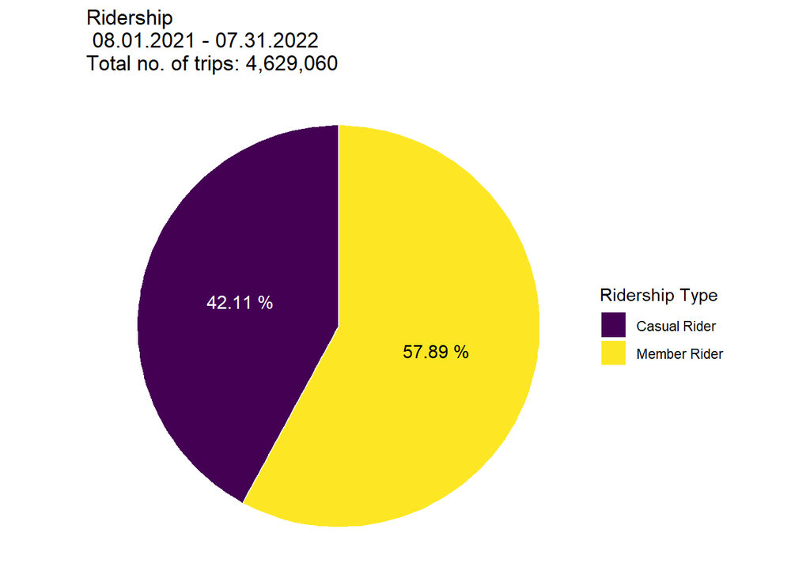

### 3.2. Visualization 2: Ridership per bike type

Create a stacked bar chart showing the proportion of bike types used by member and casual riders from 08.01.2021 to 07.31.2022.

```r
# Create the stacked bar chart using ggplot()
rides_v_type_bar <- ggplot(data=rides_v_type,
                           aes(x=member_casual,
                               y=numtrips/1000, # ridership is in unit "thousand trips/rides"
                               fill=rideable_type)) +

  ## Set bar chart to show respective riderships as values in cells (see similar comment in code for visualization 1)
  geom_bar(stat="identity")+

  ## Specify the title of the chart
  labs(title = "Ridership per Bike Type \n 08.01.2021 - 07.31.2022")+

  ## Specify x-axis label
  xlab("Ridership Type") +

  ## Specify y-axis label
  ylab("Number of Trips (thousand)")+

  ## Set light theme, i.e., white instead of gray plot background
  theme_light() +

  ## Set the title of the legends
  labs(fill = "Bike Type")+

  ## Apply viridis color palette portions in the chart
  ## Name the respective portion in the legend
  scale_fill_viridis_d(option = "viridis",
                       labels = c("Classic Bike", "Docked Bike", "Electric Bike")
                       )
```

Display the resulting chart

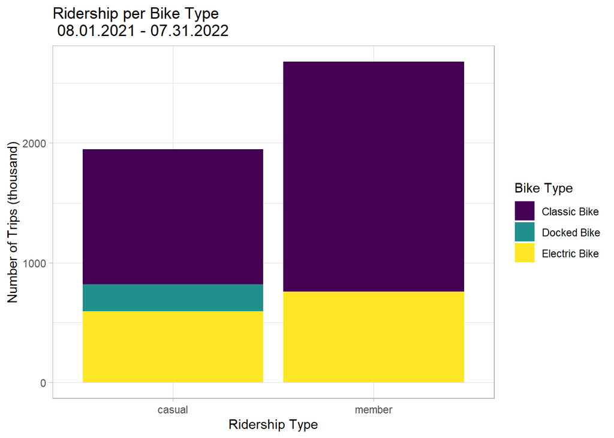

### 3.3. Visualization 3: Monthly Ridership

Create a side-by-side bar chart showing the monthly ridership from 08.01.2021 to 07.31.2022 by ridership types.

```r
# Create the side-by-side bar chart using ggplot()
rides_v_month_bar <- ggplot(data=rides_v_month,
                            aes(x=started_at_month,
                                y=numtrips/1000, # ridership is in unit "thousand trips/rides"
                                fill=member_casual)) +

  ## In geom_bar, set position = position_dodge() to specify side-by-side bars in the chart
  ## If position is not specified, the default is a stacked bar chart
  geom_bar(stat="identity", position=position_dodge())+

  ## Specify the title of the chart
  labs(title = "Monthly Ridership \n 08.01.2021 - 07.31.2022")+

  ## Set x-axis to display month name instead of number, and in the order Jan-Dec
  scale_x_continuous(
    expand = c(0, 0),
    breaks = seq(1, 12, length = 12),
    labels = c("Jan", "Feb", "Mar", "Apr", "May", "Jun",
               "Jul", "Aug", "Sep", "Oct", "Nov", "Dec"))+

  ## Specify x-axis label
  xlab("Month") +

  ## Specify x-axis label
  ylab("Number of Trips (thousand)")+

  ## Set light theme, i.e., white instead of gray plot background
  theme_light() +

  ## Apply viridis color palette portions in the chart
  ## Name the respective portion in the legend
  scale_fill_viridis_d(labels = c("Casual Rider", "Member Rider")) +

  ## Set the title of the legends
  labs(fill = "Ridership Type")
```

Display the resulting chart

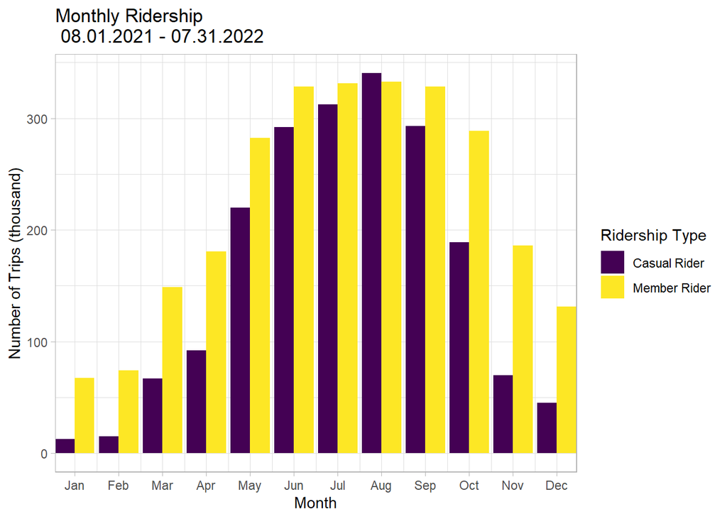

### 3.4. Visualization 4: Weekly ridership by weekday

Create heat maps showing the weekly ridership from 08.01.2021 to 07.31.2022 by ridership types, which also show possible seasonal pattern(s) of Cyclistics’ usage. Each member type has a separate heat map (2 maps created in total).

The idea to analyze, transform and visualize data in this direction as well as its execution is adapted and improved from the previous work of [Isabella Peel](https://isabellapeel.github.io/Cyclistic_Case_Study-Divvy_Bikes/Analysis_w_code.html).

```r
# Create a heat map to show most popular time of year for member riders
rides_v_YMD_mem_heat <- ggplot(
  rides_v_YMD_member,
  aes(
    x = started_at_week,

    ### Arrange the weekday from Mon-Sun on y-axis
    y = factor(rides_v_YMD_member$started_at_weekday,
               levels = c("Monday", "Tuesday", "Wednesday",
                          "Thursday", "Friday", "Saturday", "Sunday"
                          )
               ),
    fill = numtrips
    )
  ) +

  ## Use the viridis colour palette to represent the ridership of each day
  scale_fill_viridis(
    option = "D",
    direction = 1,
    name = "Number of Trips"
  ) +

  ## Create a rectangular heat map
  geom_tile(
    colour = "white",
    na.rm = FALSE
  ) +

  ## Separate the heat maps by year
  facet_wrap(
    "started_at_year",
    ncol = 1
  ) +

  ## Reverse the y-axis so that the weekdays read vertically Monday to Sunday
  scale_y_discrete(
    limits = rev
  ) +

  ## Add x-axis labels to show the months of the year
  scale_x_continuous(
    expand = c(0, 0),
    breaks = seq(1, 52, length = 12),
    labels = c("Jan", "Feb", "Mar", "Apr", "May", "Jun",
               "Jul", "Aug", "Sep", "Oct", "Nov", "Dec")
  ) +

  ## Set the light theme
  theme_light() +

  ## Remove any unnecessary labels
  theme(
    axis.title = element_blank()
  ) +

  ## Add a title
  labs(title = "Daily Ridership by Member Riders \n 08.01.2021 - 07.31.2022")

# Create a heat map to show most popular time of year for casual riders
rides_v_YMD_cas_heat <- ggplot(
  rides_v_YMD_casual,
  aes(
    x = started_at_week,

    ### Arrange the weekday from Mon-Sun on y-axis
    y = factor(rides_v_YMD_member$started_at_weekday,
               levels = c("Monday", "Tuesday", "Wednesday",
                          "Thursday", "Friday", "Saturday", "Sunday"
                          )
               ),
    fill = numtrips
    )
  ) +

  # Use the viridis colour scheme to show the popularity of each day
  scale_fill_viridis(
    option = "D",
    direction = 1,
    name = "Number of Trips",
  ) +

  # Create a rectangular heat map
  geom_tile(
    colour = "white",
    na.rm = FALSE
  ) +

  # Separate the heat maps by year
  facet_wrap(
    "started_at_year",
    ncol = 1
  ) +

  # Reverse the y-axis so that the weekdays read vertically Monday to Sunday
  scale_y_discrete(
    limits = rev
  ) +

  # Add x-axis labels to show the months of the year
  scale_x_continuous(
    expand = c(0, 0),
    breaks = seq(1, 52, length = 12),
    labels = c("Jan", "Feb", "Mar", "Apr", "May", "Jun",
               "Jul", "Aug", "Sep", "Oct", "Nov", "Dec")
  ) +

  # Set the light theme
  theme_light() +

  # Remove any unnecessary labels
  theme(
    axis.title = element_blank()
  ) +

  # Add a title
  labs(title = "Daily Ridership by Casual Riders \n 08.01.2021 - 07.31.2022")

# Combine the members only and casual riders only heat maps into one with one common legend
rides_v_YMD_mem_cas_heat <- ggarrange(
  rides_v_YMD_mem_heat,
  rides_v_YMD_cas_heat,
  ncol = 1,
  nrow = 2,
  common.legend = TRUE,
  legend = "right"
  )
```

Display the resulting heat maps

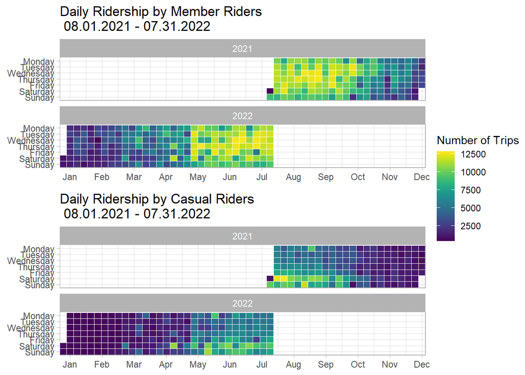

### 3.5. Visualization 5: Daily ridership by hour

The idea to analyze, transform and visualize data in this direction as well as its execution is adapted and improved from the previous work of [Isabella Peel](https://isabellapeel.github.io/Cyclistic_Case_Study-Divvy_Bikes/Analysis_w_code.html).

```r
# Convert started_at_ToD_byHr in dataframe rides_v_hr back to character
# Otherwise the labeling of the circular x-axis (with annotate()) would not be possible
rides_v_hr$started_at_ToD_byHr <- as.character(rides_v_hr$started_at_ToD_byHr)

# Create a circular bar chart to show the popularity of each hour
rides_v_hr_circular <- ggplot(rides_v_hr) +

  ## Make custom panel grid
  geom_hline(
    aes(yintercept = y),
    data.frame(y = c(0:4) * 125),
    color = "lightgrey"
  ) +

  ## Create a side-by-side bar chart
  geom_bar(
    aes(
      x = started_at_ToD_byHr,
      y = numtrips/1000,
      fill = member_casual
    ),
    stat="identity",
    position=position_dodge()
  )+

  ## Create circular bar chart which starts in the mid-line
  coord_polar(start = -0.135, direction = 1) +
  ylim(-600, 500)+

  ## Add x-axis labels showing 24 hours of a day
  annotate(
    x = 1,
    y = -50,
    label = "00:00",
    geom = "text",
    size = 2.5,
  )+
  annotate(
    x = 2,
    y = -50,
    label = "01:00",
    geom = "text",
    size = 3,
  )+
  annotate(
    x = 3,
    y = -50,
    label = "02:00",
    geom = "text",
    size = 2.5,
  ) +
  annotate(
    x = 4,
    y = -50,
    label = "03:00",
    geom = "text",
    size = 2.5,
  ) +
  annotate(
    x = 5,
    y = -50,
    label = "04:00",
    geom = "text",
    size = 2.5,
  ) +
  annotate(
    x= 6,
    y=-50,
    label = "05:00",
    geom = "text",
    size = 2.5,
  ) +
  annotate(
    x = 7,
    y = -50,
    label = "06:00",
    geom = "text",
    size = 2.5,
  ) +
  annotate(
    x = 8,
    y = -50,
    label = "07:00",
    geom = "text",
    size = 2.5,
  ) +
  annotate(
    x = 9,
    y = -50,
    label = "08:00",
    geom = "text",
    size = 2.5,
  ) +
  annotate(
    x = 10,
    y = -50,
    label = "09:00",
    geom = "text",
    size = 2.5,
  ) +
  annotate(
    x = 11,
    y = -50,
    label = "10:00",
    geom = "text",
    size = 2.5,
  ) +
  annotate(
    x = 12,
    y = -50,
    label = "11:00",
    geom = "text",
    size = 2.5,
  ) +
  annotate(
    x = 13,
    y = -50,
    label = "12:00",
    geom = "text",
    size = 2.5,
  ) +
  annotate(
    x = 14,
    y = -50,
    label = "13:00",
    geom = "text",
    size = 2.5,
  ) +
  annotate(
    x = 15,
    y = -50,
    label = "14:00",
    geom = "text",
    size = 2.5,
  ) +
  annotate(
    x = 16,
    y = -50,
    label = "15:00",
    geom = "text",
    size = 2.5,
  ) +
  annotate(
    x = 17,
    y = -50,
    label = "16:00",
    geom = "text",
    size = 2.5,
  ) +
  annotate(
    x = 18,
    y = -50,
    label = "17:00",
    geom = "text",
    size = 2.5,
  ) +
  annotate(
    x = 19,
    y = -50,
    label = "18:00",
    geom = "text",
    size = 2.5,
  ) +
  annotate(
    x = 20,
    y = -50,
    label = "19:00",
    geom = "text",
    size = 2.5,
  ) +
  annotate(
    x = 21,
    y = -50,
    label = "20:00",
    geom = "text",
    size = 2.5,
  ) +
  annotate(
    x = 22,
    y = -50,
    label = "21:00",
    geom = "text",
    size = 2.5,
  ) +
  annotate(
    x = 23,
    y = -50,
    label = "22:00",
    geom = "text",
    size = 2.5,
  ) +
  annotate(
    x = 24,
    y = -50,
    label = "23:00",
    geom = "text",
    size = 2.5,
  )+

  ## Annotate y-axis scaling labels
  annotate(
    x = 24,
    y = 125,
    label = "125,000 trips",
    geom = "text",
    size = 3,
    angle = 15
  ) +
  annotate(
    x = 24,
    y = 250,
    label = "250,000 trips",
    geom = "text",
    size = 3,
    angle = 15
  ) +
  annotate(
    x = 24,
    y = 375,
    label = "375,000 trips",
    geom = "text",
    size = 3,
    angle = 15
  ) +

  ## Apply viridis color palette
  scale_fill_viridis_d(labels = c("Casual Rider", "Member Rider")) +

  ## Set light theme
  theme_light() +

  ## Set legend title
  labs(fill = "Ridership Type")+

  ## Remove unnecessary labels
  theme(
    axis.title = element_blank(),
    axis.ticks = element_blank(),
    axis.text = element_blank(),
    legend.position = "bottom",
    legend.title = element_text(hjust = 0.5),
  )+

  ## Add title
  labs(title = "Total Ridership by Time of Day \n 08.01.2021 - 07.31.2022")
```

Display the resulting circular bar chart

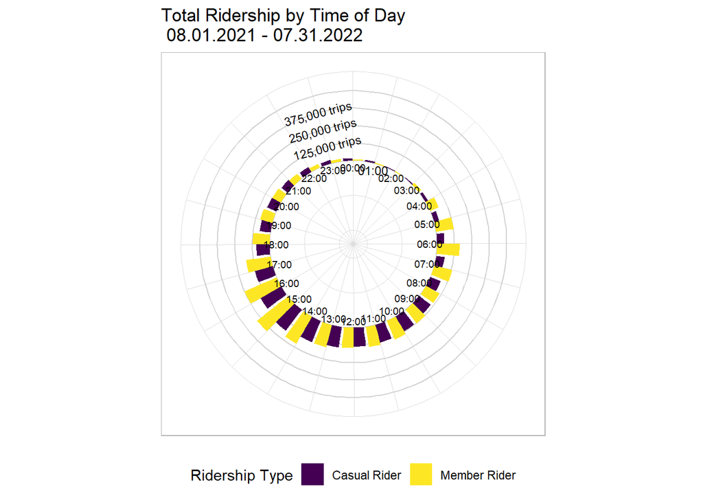

### 3.6. Visualization 6: Effect of weather on ridership

Create scatter plots showing the effect of weather (temperature, wind speed, precipitation) on daily ridership from 08.01.2021 to 07.31.2022 by ridership types.

The idea to analyze, transform and visualize data in this direction as well as its execution is adapted and improved from the previous work of [Isabella Peel](https://isabellapeel.github.io/Cyclistic_Case_Study-Divvy_Bikes/Analysis_w_code.html).

```r
# Perform garbage collection manually to free up memory in R
gc()
```

```
##             used   (Mb) gc trigger   (Mb)  max used   (Mb)
## Ncells   6328945  338.1   10185454  544.0  10185454  544.0
## Vcells 198724168 1516.2  306239187 2336.5 201458398 1537.1
```

```r
# Scatter plot 1: Effect of temperature on daily ridership
avg_temp <- ggplot(
  rides_v_weather,
  aes(
    x = avg_temp,
    y = numtrips/1000,
    color = member_casual
    )
  ) +

  ## Format scatter points
  geom_point(
    size = 2, alpha = 0.5
  ) +

  ## Add title and axis labels
  labs(
    title = "Effect of Temperature on Daily Ridership",
    x = "Average Daily Temperature (C)",
    y = "No. of Trips (thousand)"
  ) +

  ## Use viridis color palette
  scale_color_viridis_d(labels = c("Casual Rider", "Member Rider")) +

  ##  Set light theme
  theme_light() +

  ## Remove legend title and center title
  theme(
    plot.title = element_text(hjust = 0.5)
  )+

  ## Add legend title
  labs(color = "Ridership Type")


# Scatter plot 2: Effect of wind speed on daily ridership
avg_wdspd <- ggplot(
  rides_v_weather,
  aes(
    x = wind_speed,
    y = numtrips/1000,
    color = member_casual
    )
  ) +

  ## Format scatter points
  geom_point(
    size = 2, alpha = 0.5
  ) +

  ## Add title and axis labels
  labs(
    title = "Effect of Wind Speed on Daily Ridership",
    x = "Average Daily Wind Speed (m/s)",
    y = "No. of Trips (thousand)"
  ) +

  ## Use viridis colour scheme
  scale_color_viridis_d(labels = c("Casual Rider", "Member Rider")) +

  ## Set light theme
  theme_light() +

  ## Remove legend title and center title
  theme(
    plot.title = element_text(hjust = 0.5)
  )+

  ## Add legend title
  labs(color = "Ridership Type")


# Scatter plot 3: Effect of precipitation on daily ridership
avg_precip <- ggplot(
  rides_v_weather,
  aes(
    x = precipitation,
    y = numtrips/1000,
    color = member_casual
    )
  ) +

  ## Format scatter points
  geom_point(
    size = 2, alpha = 0.5
  ) +

  ## Add title and axis labels
  labs(
    title = "Effect of Precipitation on Daily Ridership",
    x = "Average Daily Precipitation (mm)",
    y = "No. of Trips (thousand)"
  ) +

  ## Use viridis colour scheme
  scale_color_viridis_d(labels = c("Casual Rider", "Member Rider")) +

  ## Set light theme
  theme_light() +

  ## Remove legend title and center title
  theme(
    plot.title = element_text(hjust = 0.5)
  )+

  ## Add legend title
  labs(color = "Ridership Type")

# Combine all 3 plots into one visualization
rides_v_weather_scatter <- ggarrange(
  avg_temp,
  avg_precip,
  avg_wdspd,
  ncol = 2,
  nrow = 2,
  common.legend = TRUE,
  legend = "bottom"
)
```

Display the resulting scatter plots

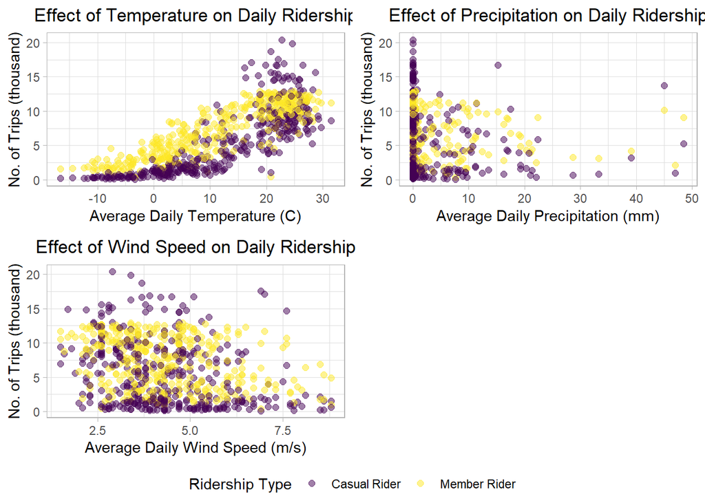

## 4. Data-visualization: Location (remaining)

### 4.1. Visualization 13: Monthly mean ride distance with corresponding standard deviation values

Create side-by-side bar charts showing mean ride distance per month per ridership types and the respective standard deviation values. Since the standard deviation values are quite large in many cases, a side-by-side bar chart is used rather than incorporating them in the mean bar chart.

With this plot being similar to those created previously, commenting is done minimally.

```r
# Mean ride distance per Month by ridership type
rides_distance_perMonth_barM <- ggplot(data=rides_duration_distance_perMonth,
                                               aes(x=started_at_month,

                                                   # Convert m to km for y-axis
                                                   y=ride_distance_mean/1000,
                                                   fill=member_casual)
                                       ) +
  geom_bar(stat="identity", position=position_dodge()) +
  labs(title = "Monthly Mean Ride Distance by Ridership Type \n 08.01.2021 - 07.31.2022")+
  scale_x_continuous(
    expand = c(0, 0),
    breaks = seq(1, 12, length = 12),
    labels = c("Jan", "Feb", "Mar", "Apr", "May", "Jun",
               "Jul", "Aug", "Sep", "Oct", "Nov", "Dec")) +
  xlab("Month") +
  ylab("Mean Ride Distance (km)") +
  theme_light() +
  scale_fill_viridis_d(labels = c("Casual Rider", "Member Rider")) +
  labs(fill = "Ridership Type")

# Standard deviation of ride distance per Month by ridership type
rides_distance_perMonth_barSd <- ggplot(data=rides_duration_distance_perMonth,
                                       aes(x=started_at_month,

                                           # Convert m to km for y-axis
                                           y=ride_distance_Sd/1000,
                                           fill=member_casual)) +
  geom_bar(stat="identity", position=position_dodge()) +
  labs(title = "Standard Deviation of Monthly Ride Distance by Ridership Type \n 08.01.2021 - 07.31.2022")+
  scale_x_continuous(
    expand = c(0, 0),
    breaks = seq(1, 12, length = 12),
    labels = c("Jan", "Feb", "Mar", "Apr", "May", "Jun",
               "Jul", "Aug", "Sep", "Oct", "Nov", "Dec")) +
  xlab("Month") +
  ylab("Stdev Value (km)")+
  theme_light() +
  scale_fill_viridis_d(labels = c("Casual Rider", "Member Rider")) +
  labs(fill = "Ridership Type")

# [Combine the graphs] Monthly ride distance situation by ridership type
rides_distance_perMonth_bar <- ggarrange(
  rides_distance_perMonth_barM,
  rides_distance_perMonth_barSd,
  ncol = 1,
  nrow = 2,
  common.legend = TRUE,
  legend = "bottom"
)
```

Display the resulting charts

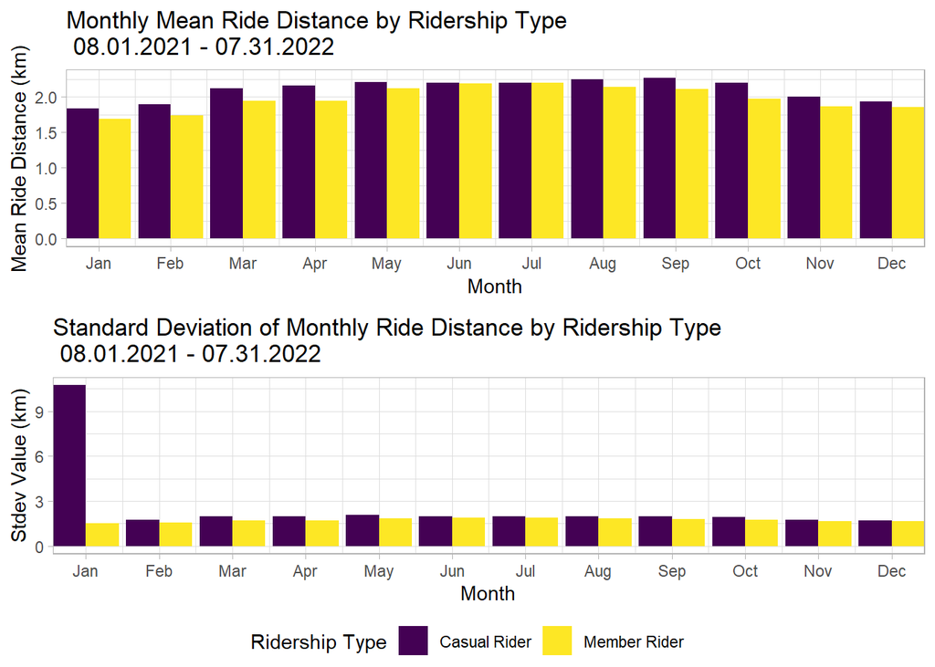

## 5. Data-visualization: Time

### 5.1. Visulaization 14: Monthly mean ride duration with corresponding standard deviation values

Create side-by-side bar charts showing mean ride duration per month per ridership types and the respective standard deviation values. Since the standard deviation values are quite large in many cases, a side-by-side bar chart is used rather than incorporating them in the mean bar chart.

With this plot being similar to those created previously, commenting is done minimally.

```r
# Mean ride duration per Month by ridership type
rides_duration_perMonth_barM <- ggplot(data=rides_duration_distance_perMonth,
                                       aes(x=started_at_month,
                                           # Convert seconds to minutes for y-axis
                                           y=ride_duration_mean/60,
                                           fill=member_casual)) +
  geom_bar(stat="identity", position=position_dodge())+
  labs(title = "Monthly Mean Ride Duration by Ridership Type \n 08.01.2021 - 07.31.2022") +
  scale_x_continuous(
    expand = c(0, 0),
    breaks = seq(1, 12, length = 12),
    labels = c("Jan", "Feb", "Mar", "Apr", "May", "Jun",
               "Jul", "Aug", "Sep", "Oct", "Nov", "Dec")) +
  xlab("Month") +
  ylab("Mean Ride Duration (min)")+
  theme_light() +
  scale_fill_viridis_d(labels = c("Casual Rider", "Member Rider")) + #use viridis color scheme
  labs(fill = "Ridership Type")

# Standard deviation of ride duration per Month by ridership type
rides_duration_perMonth_barSd <- ggplot(data=rides_duration_distance_perMonth,
                                               aes(x=started_at_month,

                                                   # Convert seconds to minutes for y-axis
                                                   y=ride_duration_Sd/60,
                                                   fill=member_casual)) +
  geom_bar(stat="identity", position=position_dodge())+
  labs(title = "Standard Deviation of Monthly Ride Duration by Ridership Type \n 08.01.2021 - 07.31.2022")+
  scale_x_continuous(
    expand = c(0, 0),
    breaks = seq(1, 12, length = 12),
    labels = c("Jan", "Feb", "Mar", "Apr", "May", "Jun",
               "Jul", "Aug", "Sep", "Oct", "Nov", "Dec")) +
  xlab("Month") +
  ylab("Stdev Value (min)") +
  theme_light() +
  scale_fill_viridis_d(labels = c("Casual Rider", "Member Rider")) +
  labs(fill = "Ridership Type")

## [Combine the graphs] Monthly ride duration situation by ridership type
rides_duration_perMonth_bar <- ggarrange(
  rides_duration_perMonth_barM,
  rides_duration_perMonth_barSd,
  ncol = 1,
  nrow = 2,
  common.legend = TRUE,
  legend = "bottom"
)
```

Display the resulting charts

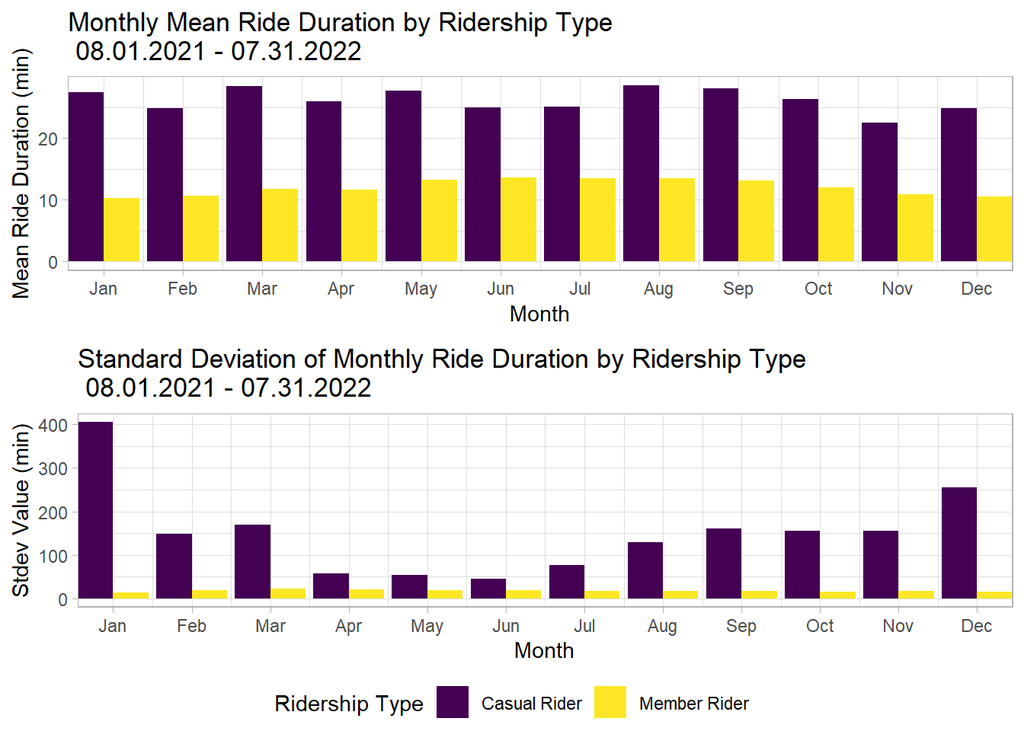

## 6. Save the resulting visualizations as .png files

The visualizations are saved individually (rather than in bulk using the for loop) to allow individual customization of each figure’s scale.

```r
ggsave(
  "rides_v_riderships_pie.png",
  plot = rides_v_riderships_pie,
  device = NULL,
  path = "C:/Users/phucm/OneDrive/My Stuffs/Academic Materials/Books and Materials_by time period/2018-2020_RWTH-AACHEN/01_ADDITIONAL CLASSES/Coursera_Google-CC_Data-Analytics/C08_Capstone/CS1_Viz/Plots",
  scale = 3,
  bg = "white"
)
ggsave(
  "rides_v_type_bar.png",
  plot = rides_v_type_bar,
  device = NULL,
  path = "C:/Users/phucm/OneDrive/My Stuffs/Academic Materials/Books and Materials_by time period/2018-2020_RWTH-AACHEN/01_ADDITIONAL CLASSES/Coursera_Google-CC_Data-Analytics/C08_Capstone/CS1_Viz/Plots",
  scale = 3,
  bg = "white"
)
ggsave(
  "rides_v_month_bar.png",
  plot = rides_v_month_bar,
  device = NULL,
  path = "C:/Users/phucm/OneDrive/My Stuffs/Academic Materials/Books and Materials_by time period/2018-2020_RWTH-AACHEN/01_ADDITIONAL CLASSES/Coursera_Google-CC_Data-Analytics/C08_Capstone/CS1_Viz/Plots",
  scale = 3,
  bg = "white"
)
ggsave(
  "rides_v_YMD_mem_cas_heat.png",
  plot = rides_v_YMD_mem_cas_heat,
  device = NULL,
  path = "C:/Users/phucm/OneDrive/My Stuffs/Academic Materials/Books and Materials_by time period/2018-2020_RWTH-AACHEN/01_ADDITIONAL CLASSES/Coursera_Google-CC_Data-Analytics/C08_Capstone/CS1_Viz/Plots",
  scale = 5,
  bg = "white"
)
ggsave(
  "rides_v_hr_circular.png",
  plot = rides_v_hr_circular,
  device = NULL,
  path = "C:/Users/phucm/OneDrive/My Stuffs/Academic Materials/Books and Materials_by time period/2018-2020_RWTH-AACHEN/01_ADDITIONAL CLASSES/Coursera_Google-CC_Data-Analytics/C08_Capstone/CS1_Viz/Plots",
  scale = 5,
  bg = "white"
  )
ggsave(
  "rides_v_weather_scatter.png",
  plot = rides_v_weather_scatter,
  device = NULL,
  path = "C:/Users/phucm/OneDrive/My Stuffs/Academic Materials/Books and Materials_by time period/2018-2020_RWTH-AACHEN/01_ADDITIONAL CLASSES/Coursera_Google-CC_Data-Analytics/C08_Capstone/CS1_Viz/Plots",
  scale = 5,
  bg = "white"
)
ggsave(
  "rides_distance_perMonth_bar.png",
  plot = rides_distance_perMonth_bar,
  device = NULL,
  path = "C:/Users/phucm/OneDrive/My Stuffs/Academic Materials/Books and Materials_by time period/2018-2020_RWTH-AACHEN/01_ADDITIONAL CLASSES/Coursera_Google-CC_Data-Analytics/C08_Capstone/CS1_Viz/Plots",
  scale = 5,
  bg = "white"
)
ggsave(
  "rides_duration_perMonth_bar.png",
  plot = rides_duration_perMonth_bar,
  device = NULL,
  path = "C:/Users/phucm/OneDrive/My Stuffs/Academic Materials/Books and Materials_by time period/2018-2020_RWTH-AACHEN/01_ADDITIONAL CLASSES/Coursera_Google-CC_Data-Analytics/C08_Capstone/CS1_Viz/Plots",
  scale = 5,
  bg = "white"
)
```